# act_report

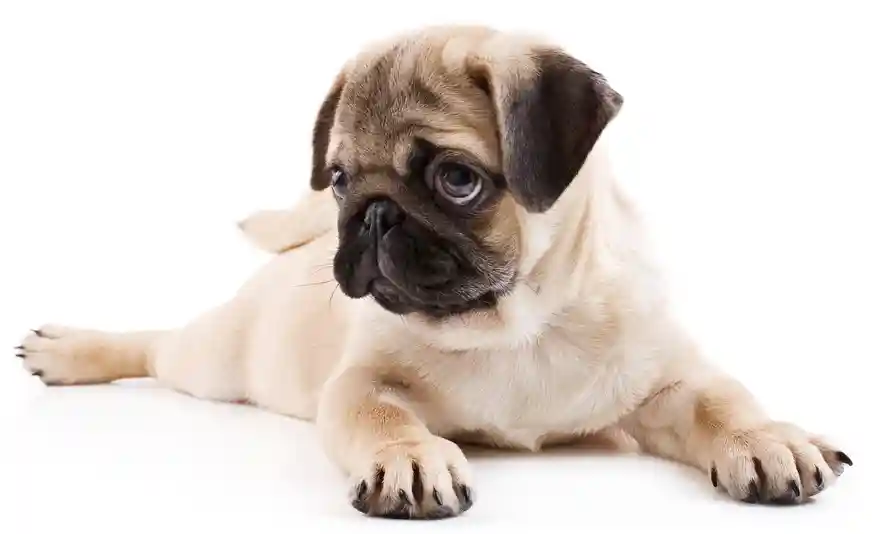

The "We Rate Dogs" Twitter archive contains over 5000 tweets, which have been filtered to create the enhanced archive that forms the basis of this analysis. The goal of this project is to wrangle the data - gather, assess, and clean - into a tidy dataset, and then provide analyses and visualizations.

After i did the first four steps :

- Step 1: Gathering data from multiple sources
- Step 2: Assessing data in two ways : Visual assessment and Programmatic assessment . then i wrote some qualities issues and some tinndes issues in evert data sourse i gatherd.
- Step 3: Cleaning data from all the qualities issues and some tinndes issues to make the workspace better.
- Step 4: Storing data in (''twitter_archive_master.csv')

now i will show you the step 5 :

## Analyzing, and visualizing data

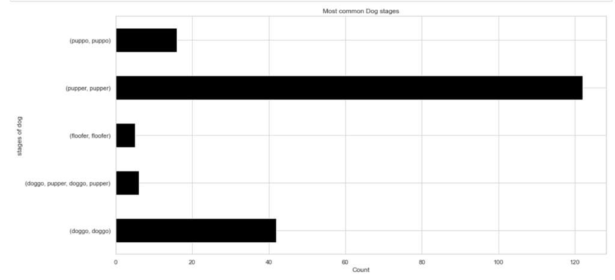

- as we can see that most common dog stage was (pupper) , its above 120 .
- in the other hand the most uncommon dog stage was (floofer) its down than 20 .

and we can see it here in onther graphic

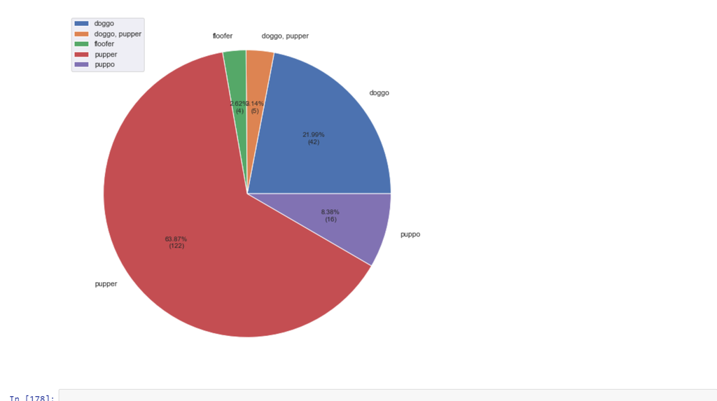

and here i explore the rating :

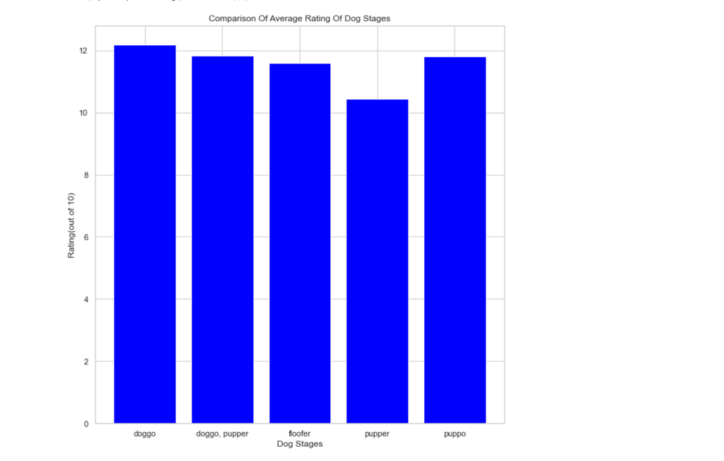

- from the graphic we can see the whole rating between ( 10 - 13)
- also we can say that the pupper is less than the others
- and the best rating is ( doggo ) its more than 12
- also even the rating from 10 and all the average rating above 10